# On the use of a local $\hat{R}$ to improve MCMC convergence diagnostic: Multivariate examples using OpenTurns

Théo Moins, Julyan Arbel, Anne Dutfoy, Stéphane Girard

```python
import numpy as np
import matplotlib.pyplot as plt
import openturns as ot
import openturns.viewer as viewer
from IPython.core.display import HTML


from r_functions import trad_rhat, multivariate_local_rhat, multivariate_directed_local_rhat, \
                        multivariate_grid_for_R, all_local_rhat, multivariate_rhat_infinity, \
                        rhat_infinity_max_directions, theoretical_R, theoretical_R_inf_2d, \
                        Rhat_exp


plt.rcParams['figure.figsize'] = [12, 8]
plt.rcParams['figure.dpi'] = 100
```

In all the examples we suppose that the margins are uniform to analyse $\hat{R}_\infty$ only as a function of the copulas.

## 1. Normal Copula

We consider bivariate Normal copulas on our $m$ chains:

\begin{equation*} C_j(\boldsymbol{u}) = \Phi_{\boldsymbol{R}_j}(\Phi^{-1}({u_1}), \ldots, \Phi^{-1}({u_d})), \quad \text{with} \quad \Phi_{\boldsymbol{R}_j} \text{ c.d.f of } \mathcal{N}(0,\boldsymbol{R}_j) \end{equation*}

The choice of $\boldsymbol{R}_j$ is the following:

\begin{align*} \boldsymbol{R}_j &= \begin{pmatrix} 1 & 0\\ 0 & 1 \end{pmatrix} \quad \text{if} \quad j \in \{1, \ldots, m-1\}, \\ \text{And } \boldsymbol{R}_m &= \begin{pmatrix} 1 & \rho_m\\ \rho_m & 1 \end{pmatrix} \quad \text{with} \quad \rho_m \in (-1, 1) \end{align*}

```python
def dist_gaussian_exp(m, rho):

    R = ot.CorrelationMatrix(2)
    R[0,1] = 0
    R[1,0] = 0

    dist = ot.NormalCopula(R)

    R_m = ot.CorrelationMatrix(2)
    R_m[0,1] = rho
    R_m[1,0] = rho

    dist_m = ot.NormalCopula(R_m)

    return [dist]*(m-1)+[dist_m]
```

Example with $\rho_m = 0.8$:

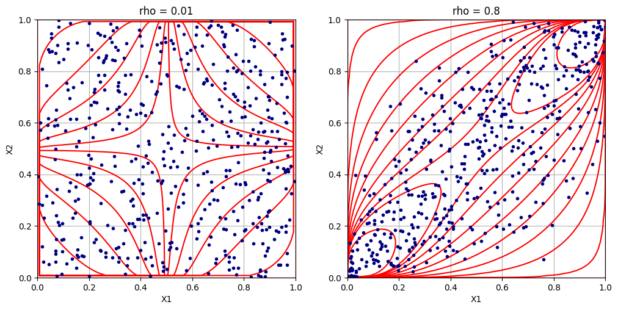

```python
n = 500
d = 2

fig, axs = plt.subplots(1,2)

rho_list = [0.01, 0.8]

for i,rho in enumerate(rho_list):
    dist = dist_gaussian_exp(m, rho)[-1]

    cloud = ot.Cloud(dist.getSample(n), 'navyblue', 'bullet', 'chain 1, ... M-1')
    myGraph = ot.Graph('',
                       'X1', 'X2', True, 'topleft')
    myGraph.setLegendPosition('bottomright')
    myGraph.add(cloud)
    pdf_draw = dist.drawPDF()
    myGraph.add(pdf_draw)
    myGraph.setColors(["navyblue"]+ ["red"]*11)

    axs[i].set_title("rho = {}".format(rho))
    viewer.View(myGraph, figure=fig, axes=[axs[i]], add_legend=False, square_axes=True)
```

### Replication of $\hat{R}_\infty$ for different value of $\rho_m$

With different value of $\rho_m$, we replicate 10 times the experiment and report the corresponding value of $\hat{R}_\infty$.

The theoretical counterparts can be computed thanks to the `computeCDF` method in OpenTURN.

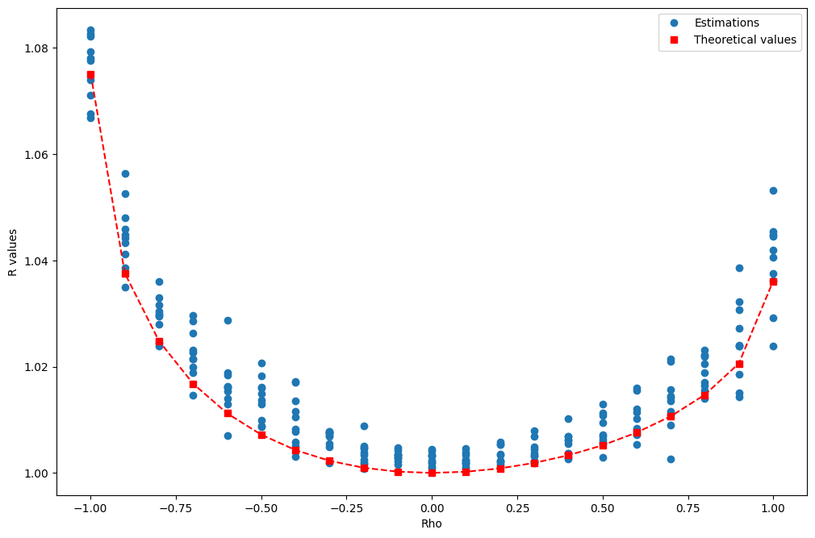

```python
n = 500
m = 2
nb_rep = 10

rho_val = np.linspace(-0.999, 0.999, 21)

x_val = []
rhat_val = []
r_theoretical = []

for rho in rho_val:
#     print("Rho = {:.2f}\r".format(rho), end="")
    dist_list = dist_gaussian_exp(m, rho)
    for i in range(nb_rep):
        rhat_val.append(Rhat_exp(n, m, dist_list))
        x_val.append(rho)
    r_theoretical.append(theoretical_R_inf_2d(dist_list))

plt.plot(x_val, rhat_val, "o", label = "Estimations")
plt.plot(rho_val, r_theoretical, linestyle="dashed", color="red")
plt.plot(rho_val, r_theoretical, "rs", label = "Theoretical values")
plt.xlabel("Rho")
plt.ylabel("R values")
plt.legend()
plt.show()
```

This illustates the influence of the dependence direction in the sensitivity of $\hat{R}_\infty$ (see Section 3.3): in dimension two, $\hat{R}_\infty$ is more sensitive in the negative dependence of the two variables than in the positive one.

When $m=2$, the two theoretical value when $|\rho_m| \to 1$ are known and are equal to $\left(\sqrt{7/6} , \sqrt{1/2 + 1/\sqrt{3}}\right) \approx (1.08, 1.04)$ for the negative and positive comonotonic dependence.

## 2. Mixture of Copulas : Min and Independant copula

In this example we suppose that all the chains are distributed according to an independent copula, except the last which is a mixture of the min and independant copula:

\begin{align*} C_j(\boldsymbol{u}) &= \Pi(\boldsymbol{u}), \quad \forall j \in \{1, \ldots, m-1\} \\ C_m(\boldsymbol{u}) &= \theta. M(\boldsymbol{u}) + (1-\theta). \Pi(\boldsymbol{u}), \quad \theta \in (0,1) \end{align*}

```python
def dist_mixture_exp(m, theta):

    dist = ot.IndependentCopula(2)

    dist_m = ot.Mixture([ot.MinCopula(2), ot.IndependentCopula(2)], [t, 1-t])

    return [dist]*(m-1)+[dist_m]
```

### Copula plot for the last chain for different value of $\theta$

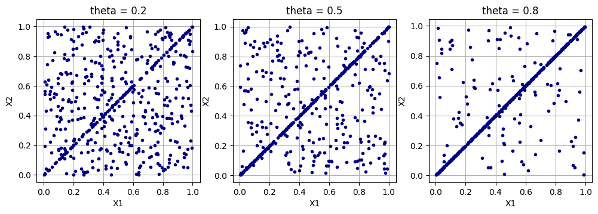

```python
n = 500
d = 2

fig, axs = plt.subplots(1,3)


theta_list = [0.2, 0.5, 0.8]

for i,t in enumerate(theta_list):

    dist = dist_mixture_exp(m, t)[-1]

    cloud = ot.Cloud(dist.getSample(n), 'navyblue', 'bullet', 'chain 1, ... M-1')
    myGraph = ot.Graph('',
                       'X1', 'X2', True, 'topleft')
    myGraph.setLegendPosition('bottomright')
    myGraph.add(cloud)

    axs[i].set_title("theta = {}".format(t))
    viewer.View(myGraph, figure=fig, axes=[axs[i]], add_legend=False, square_axes=True)
```

### Replication of $\hat{R}_\infty$ for different value of $\theta$

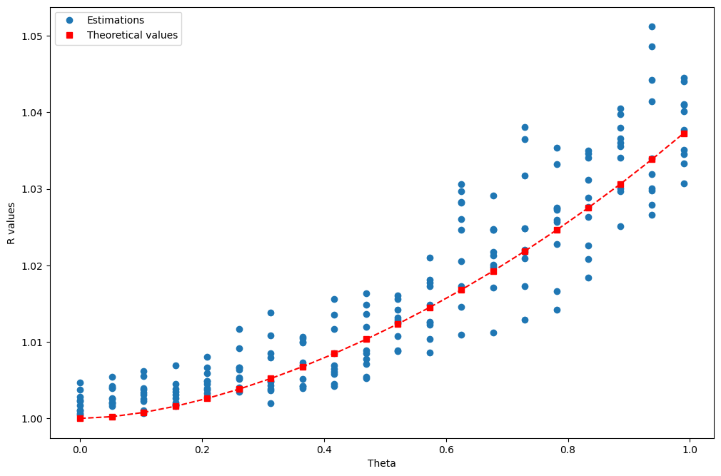

```python
n = 500
m = 2
nb_rep = 10

theta_val = np.linspace(0, 0.99, 20)

x_val = []
rhat_val = []
r_theoretical = []

for t in theta_val:
#     print("Theta = {:.2f}\r".format(t), end="")
    dist_list = dist_mixture_exp(m, t)
    for i in range(nb_rep):
        rhat_val.append(Rhat_exp(n, m, dist_list))
        x_val.append(t)
    r_theoretical.append(theoretical_R_inf_2d(dist_list))

plt.plot(x_val, rhat_val, "o", label = "Estimations")
plt.plot(theta_val, r_theoretical, linestyle="dashed", color="red")
plt.plot(theta_val, r_theoretical, "rs", label = "Theoretical values")
plt.xlabel("Theta")
plt.ylabel("R values")
plt.legend()
plt.show()
```

We find again a convergence to the theoretical value of $\sqrt{1/2 + 1/\sqrt{3}} \approx 1.04$ when $\theta \to 1$.

However, the variance of the estimator $\hat{R}_\infty$ of $R_\infty$ seems to increase as the dissimilarity between the chains increases.

## 3. Gumbel copula

In this example we consider Gumbel copulas for the chains

\begin{equation*} C_j(u_1, u_2) = \exp(-((-\log(u_1))^{\theta_j} + (-\log(u_2))^{\theta_j}))^{1/\theta_j}), \quad \forall j \in \{1, \ldots, m\} \end{equation*}

The parameter $\theta \geq 1$ is fixed by default to $2$ for all the chains except the last one: \begin{align*} \theta_j &= 2, \quad \forall j \in \{1, \ldots, m-1\}\\ \theta_m &\geq 2 \end{align*}

```python
def dist_gumbel_exp(m, theta):

    dist = ot.GumbelCopula(2)

    dist_m = ot.GumbelCopula(theta)

    return [dist]*(m-1)+[dist_m]
```

### Example of Gumbel copulas

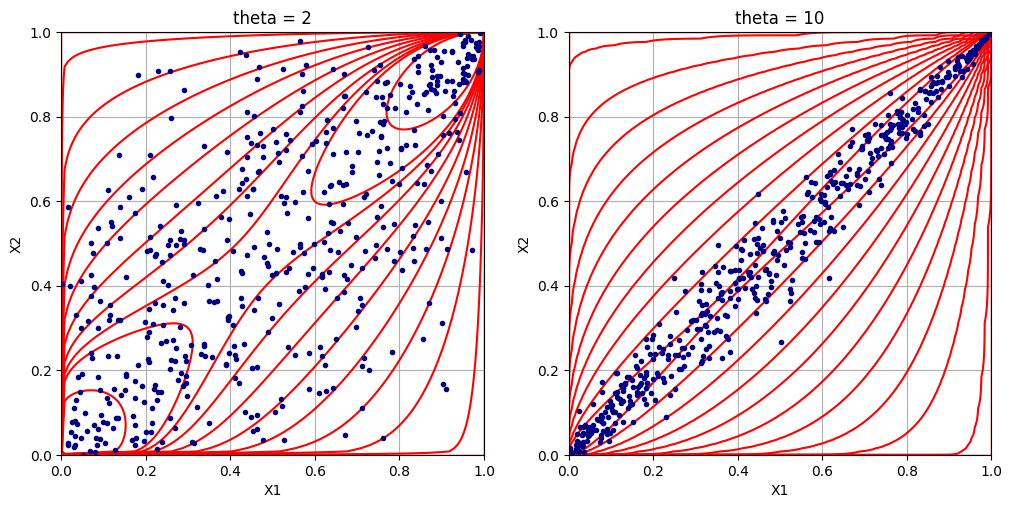

```python
fig, axs = plt.subplots(1,2)

theta_list = [2, 10]

for i,t in enumerate(theta_list):

    dist = dist_gumbel_exp(m, t)[-1]

    cloud = ot.Cloud(dist.getSample(n), 'navyblue', 'bullet', 'chain 1, ... M-1')
    myGraph = ot.Graph('',
                       'X1', 'X2', True, 'topleft')
    myGraph.setLegendPosition('bottomright')
    myGraph.add(cloud)
    pdf_draw = dist.drawPDF()
    myGraph.add(pdf_draw)
    myGraph.setColors(["navyblue"]+ ["red"]*11)

    axs[i].set_title("theta = {}".format(t))
    viewer.View(myGraph, figure=fig, axes=[axs[i]], add_legend=False, square_axes=True)
```

### Replication of $\hat{R}_\infty$ for different value of $\theta_m$

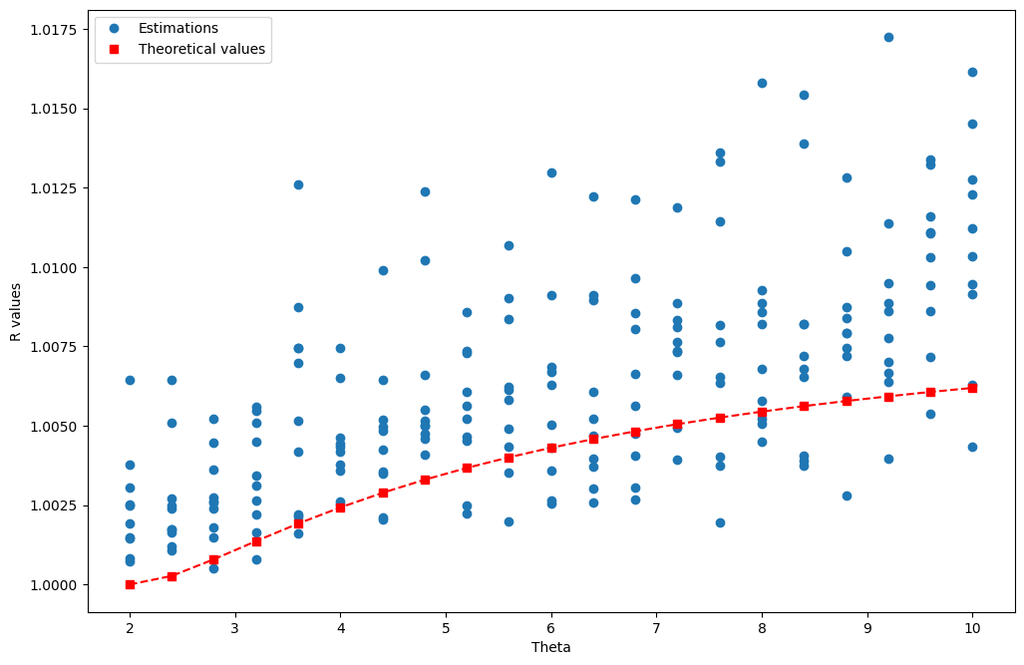

```python
n = 500
m = 2
nb_rep = 10

theta_val = np.linspace(2, 10, 21)

x_val = []
rhat_val = []
r_theoretical = []

for t in theta_val:
#     print("Theta = {:.2f}\r".format(t), end="")
    dist_list = dist_gumbel_exp(m, t)
    for i in range(nb_rep):
        rhat_val.append(Rhat_exp(n, m, dist_list))
        x_val.append(t)
    r_theoretical.append(theoretical_R_inf_2d(dist_list))

plt.plot(x_val, rhat_val, "o", label = "Estimations")
plt.plot(theta_val, r_theoretical, linestyle="dashed", color="red")
plt.plot(theta_val, r_theoretical, "rs", label = "Theoretical values")
plt.xlabel("Theta")
plt.ylabel("R values")
plt.legend()
plt.show()
```

We can see here that $\hat{R}_\infty$ is quite insensitive to this difference in distribution. Considering $\hat{R}^{-}_\infty$ instead which the computation on $\mathbb{I}\{\theta_1^{(\cdot)} \leq x_1, \theta_2^{(\cdot)} \geq x_2\}$ (see Section 3.3) allows to be more sensitive as we are in dimension two:

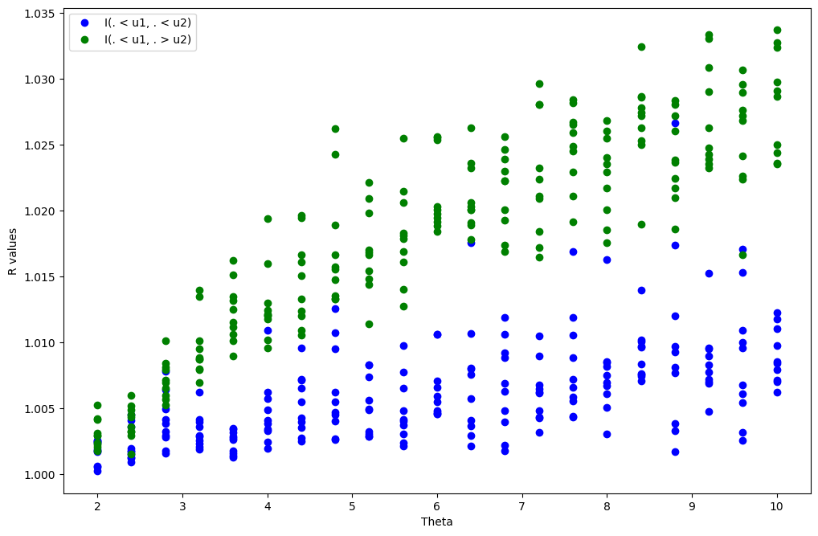

```python
n = 500
m = 2
nb_rep = 10

theta_val = np.linspace(2, 10, 21)

x_val = []
rhat_val = []
rhat_val2 = []

for t in theta_val:
#     print("Theta = {:.2f}\r".format(t), end="")
    dist_list = dist_gumbel_exp(m, t)
    for i in range(nb_rep):
        rhat_val.append(Rhat_exp(n, m, dist_list))
        rhat_val2.append(Rhat_exp(n, m, dist_list, direction = [0,1]))
        x_val.append(t)

plt.plot(x_val, rhat_val, "bo", label="I(. < u1, . < u2)")
plt.plot(x_val, rhat_val2, "go", label="I(. < u1, . > u2)")
plt.xlabel("Theta")
plt.ylabel("R values")
plt.legend()
plt.show()
```